# Activity Recognition

Pouria Shirasb

Winter 2016

# Overview

Using the dataset http://groupware.les.inf.puc-rio.br/har (see the section on the Weight Lifting Exercise Dataset), we would like to predict “classe” variable given all the other measurements. After preprocessing the data, we train a random forest model to make predictions with a reasonable accuracy.

# Preprocess

Download the data from [here](https://d396qusza40orc.cloudfront.net/predmachlearn/pml-training.csv) and load it into R:

```r
library(caret)
library(ggplot2)
library(randomForest)
library(corrplot)

# Load the data
if(!file.exists("pml-training.csv")) {
    url = "https://d396qusza40orc.cloudfront.net/predmachlearn/pml-training.csv"
    download.file( url      = url
                 , method   = "auto"
                 , destfile = "pml-training.csv")
}

data = read.csv("pml-training.csv", as.is = T)
```

After a quick look at the data, we notice that there are a lot of NA values, so we get rid of the columns that have more than 5% missing values. We also get rid of the columns 1:6 since they are mostly meta data and seem irrelevant for prediction. Then, split the data 60%, 40% into training and test sets:

```r
# Only include columns that have less than %5 missing values
pMiss <- function(x) {
    sum((x == "" | is.na(x))) /length(x)*100
}
na_ratio = apply(data, 2, pMiss)
data     = data[,na_ratio < 5]

# Convert "classe" to factor
data$classe = factor(data$classe)

# Strip away the first 6 columns
data = data[,7:60]

# Split data into training and test sets
ind = createDataPartition(data$classe, p=0.6, list=F)
data.train.x = data[ ind,-54]
data.train.y = data[ ind, 54]
data.test.x  = data[-ind,-54]
data.test.y  = data[-ind, 54]
```

# Exploratory analysis

Let’s look at the distribution of response variable to check for skewness:

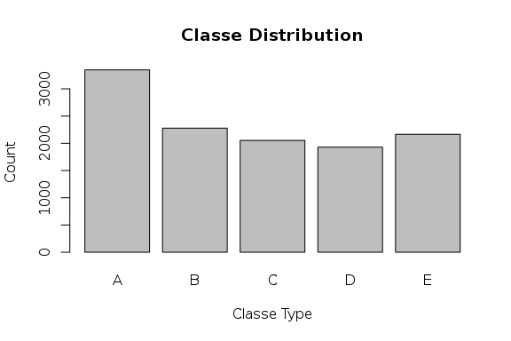

```r
# Exploratory data analysis
barplot(table(data.train.y)
       , main = "Classe Distribution"
       , xlab = "Classe Type"
       , ylab = "Count"
       )
```

We can see that classe “A” appears to have higher density than the rest of the categories, however, since the difference is not too big and the rest have approximately the same density, there is no reason for concern. Next, we will look at the correlation heatmap to see the relationship between predictors:

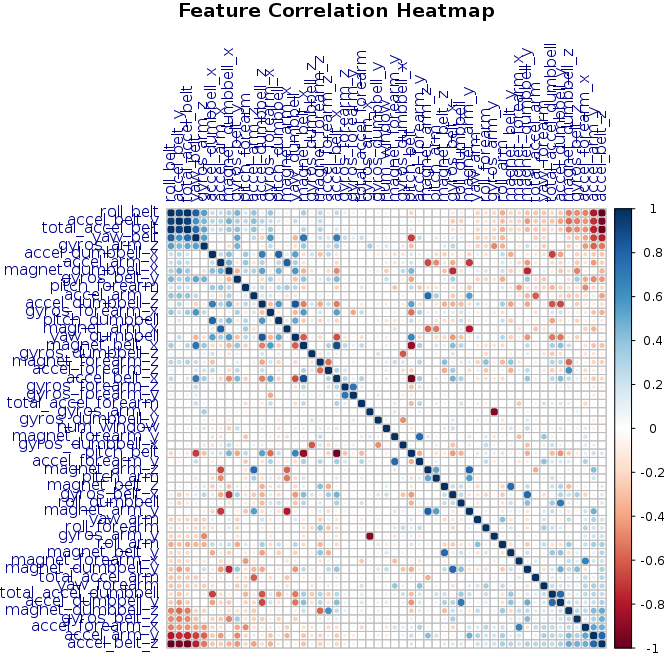

```r
cormat = cor(data.train.x)
corrplot( cormat
        , method = "circle"
        , type   = "full"
        , order  = "FPC"
        , title  = "Feature Correlation Heatmap"
        , tl.col = "darkblue"
        , mar    = c(0,0,1,0)
        )
```

Looks like with a few exceptions, the predictors are mostly only weakly correlated, which means we should use them all in our prediction model. Also, it is important to note that, since we have enough samples, i.e., the ratio of number of features over number of samples is quite low, we do not need to perform any dimensitonality reduction or other preprocessing to reduce our feature space any further in order to avoid overfitting.

# Prediction Model

Using *randomForest* library in R, we fit a random forest using all the predictors outlined above and perform a prediction on the test set to get the test standard error:

```r
# build a random forest
model = randomForest( x     = data.train.x
                    , y     = data.train.y
                    , xtest = data.test.x
                    , ytest = data.test.y
                    , keep.forest = T
                    )

print(model)
```

```
##
## Call:
##  randomForest(x = data.train.x, y = data.train.y, xtest = data.test.x,      ytest = data.test.y, keep.forest = T)
##                Type of random forest: classification
##                      Number of trees: 500
## No. of variables tried at each split: 7
##
##         OOB estimate of  error rate: 0.4%
## Confusion matrix:
##      A    B    C    D    E  class.error
## A 3346    2    0    0    0 0.0005973716
## B    7 2268    4    0    0 0.0048266784
## C    0    8 2042    4    0 0.0058422590
## D    0    0   18 1910    2 0.0103626943
## E    0    0    0    2 2163 0.0009237875
##                 Test set error rate: 0.4%
## Confusion matrix:
##      A    B    C    D    E class.error
## A 2232    0    0    0    0 0.000000000
## B    4 1509    5    0    0 0.005928854
## C    0    8 1360    0    0 0.005847953
## D    0    0    7 1279    0 0.005443235
## E    0    0    0    7 1435 0.004854369
```

And a more in-depth summary of prediction on the test set:

```r
pred = predict(model, newdata = data.test.x)
cm   = confusionMatrix(data = pred, reference = data.test.y)
print(cm)
```

```
## Confusion Matrix and Statistics
##
##           Reference
## Prediction    A    B    C    D    E
##          A 2232    2    0    0    0
##          B    0 1514    3    0    0
##          C    0    2 1365    4    0
##          D    0    0    0 1282    4
##          E    0    0    0    0 1438
##
## Overall Statistics
##
##                Accuracy : 0.9981
##                  95% CI : (0.9968, 0.9989)
##     No Information Rate : 0.2845
##     P-Value [Acc > NIR] : < 2.2e-16
##
##                   Kappa : 0.9976
##  Mcnemar's Test P-Value : NA
##
## Statistics by Class:
##
##                      Class: A Class: B Class: C Class: D Class: E
## Sensitivity            1.0000   0.9974   0.9978   0.9969   0.9972
## Specificity            0.9996   0.9995   0.9991   0.9994   1.0000
## Pos Pred Value         0.9991   0.9980   0.9956   0.9969   1.0000
## Neg Pred Value         1.0000   0.9994   0.9995   0.9994   0.9994
## Prevalence             0.2845   0.1935   0.1744   0.1639   0.1838
## Detection Rate         0.2845   0.1930   0.1740   0.1634   0.1833
## Detection Prevalence   0.2847   0.1933   0.1747   0.1639   0.1833
## Balanced Accuracy      0.9998   0.9984   0.9984   0.9981   0.9986
```

Which yeilds an accuracy of 0.9980882 , with a 95% confidence interval of (0.9968487, 0.9989296) on the test set. As an added bonus, let’s take a look at the importance of the predictors in the model:

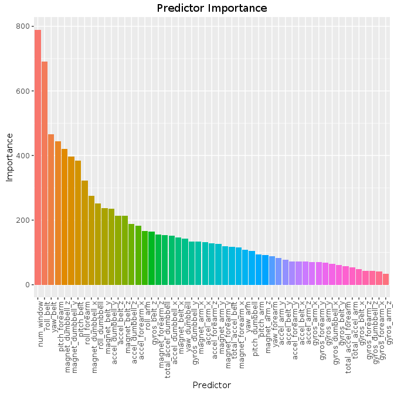

```r
x = importance(model)
sorted = order(x, decreasing=T)
df = data.frame( "Predictor"  = factor(row.names(x)[sorted]
                                      , levels = row.names(x)[sorted]
                                      )
               , "Importance" = x[sorted,]
               )
g = ( ggplot(df, aes(Predictor, Importance, fill = Predictor))
    + geom_bar(stat="identity")
    + theme(axis.text.x = element_text(angle = 90, hjust=1))
    + theme(legend.position = "none")
    + ggtitle("Predictor Importance")
    )
print(g)
```